# Introducción a R y Rstudio

2022-10-24

## 1. Introducción

En este taller usted aprenderá a reconocer los distintos elementos en la interfaz del RStudio, estructuras en R y manejo de datos con Tidyverse. Este taller se realizará mediante el uso de una guía de aprendizaje.

## 2. Objetivos

- Recordar que es R y RStudio.
- Reconocer la interfaz de RStudio.
- Describir las estructuras básicas en R: vectores, matrices, bases de datos y listas.
- Reconocer el proceso de importación, exportación y transformación de bases de datos con tidyverse.
- Describir el proceso de creación de funciones

## 3. Conceptos básicos a desarrollar

En esta práctica se desarrollarán los siguientes conceptos:

- Estructuras básicas en R: vectores, matrices, bases de datos y listas.
- Importación, exportación y transformación de bases de datos.

## 4. Introducción a R

R es un lenguaje de programación libre sucesor del lenguaje S. Fue creado por Ross Ihaka y Robert Gentleman en 1991 para uso en la enseñanza, posteriormente en 1993 fue difundido entre la comunidad de usuarios de S. Fue hasta 1995 que por motivación de Martin Mächler de la ETH Zurich R fue lanzado como software libre con código fuente disponible por ftp bajo los términos de la licencia general GNU de la Free Software Foundation.

R además de ser un lenguaje de programación es un entorno para computación estadística y creación de gráficos. [R-project](https://cran.r-project.org/doc/html/interface98-paper/paper_2.html)

## 5. Ambiente de R

La parte visual de RStudio esta compuesta por 4 áreas principalmente:

[figure not shown]

1. Editor: Esta sección es fundamental para la reproducibilidad del código. Este editor permite guardar el código para que sea usado en futuras ocasiones. El código puede ser ejecutado en esta sección posicionando el cursor de texto al final de la línea de código que se ejecutará o seleccionando la misma y empleando el comando control+enter para windows o command+enter para mac.
2. Entorno: En esta sección se pueden visualizar los objetos y funciones creados o importados en la sección de R. Objetos como vectores, matrices, arreglos, data frames, listas, objetos tipo ggplot, entre otros.
3. Consola: Esta sección es donde se ejecuta el código. No solo se ejecuta el código que se ejecute en el editor, sino también el código puede escribirse aquí y ejecutarse presionando enter. Sin embargo, cuando el código se ejecuta directamente en la consola este no se almacena y cuando se cierra la sesión de R este se pierde.
4. Visualizador: En esta sección se pueden visualizar los archivos en “Files”, los gráficos en “Plots”, los paquetes que ya están instalados en “Packages”, la ayuda de R con información de los paquetes y el funcionanmiento en “Help” y páginas web en “Viewer”.

## 6. Configuración de un proyecto en R

Una de las grandes ventajas de usar RStudio es la posibilidad de usar los Proyectos en R (R Project)(indicado por un archivo `.Rproj`) lo que permite organizar el espacio de trabajo, el historial y los documentos fuente.

Para crear un Proyecto en R, siga los siguientes pasos:

[figure not shown]

Screenshot New Directory

Al final, su proyecto debería parecerse a esta imagen

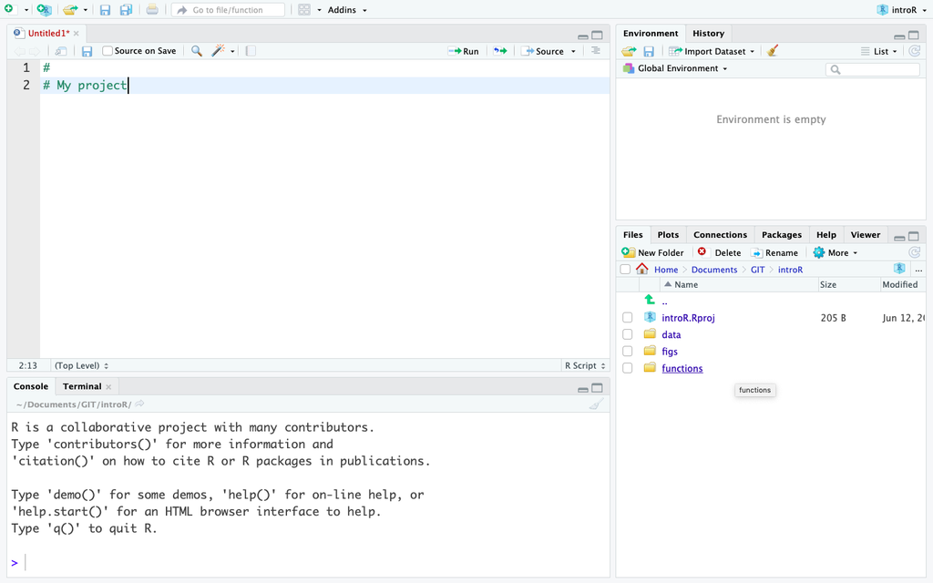

Screenshot R Project

Al final, su proyecto debería parecerse a esta imagen

## 7. Datos en R

R tiene la capacidad de almacenar y procesar distintos tipos de datos. Entre estos se encuentran:

1. Datos numéricos fraccionados (double. Ej: 3.3)
2. Datos enteros (integer. Ej: 3)
3. Datos en caracteres (character)
4. Operadores aritméticos (Ej: +, -, *)
5. Operadores de comparación (Ej: <, >, ==, >=, <=, !=)
6. Tipos de datos booleanos/ Datos lógicos (logic. Ej: FALSE, TRUE)
7. Operadores booleanos (& (and), | (or), ! (not))
8. Datos factor (factor. Sirven para categorizar. Ej: femenino, masculino, otro o primero, segundo.)
9. Datos tipo fechas (date. Ej: 01/01/2022)
10. Datos NA, NAN e Inf

### Variables

Hay una forma que tiene R de almacenar un dato importante la cual es mediante el uso de variables. Las variables son objetos de R que pueden almacenar datos nuevos, resultados de operaciones, entre otros. Y pueden ser actualizadas si es necesario. Estas variables tienen un nombre que las identifica de manera única, de modo que si otra variable tiene el mismo nombre los datos que se encontraban en esa variable se perderían. Para crear estos nombres hay algunas reglas básicas:

- Usar minúsculas
- Siempre debe comenzar con letras, a continuación pueden ir letras, números o el símbolo de guión bajo “_”
- no usar espacios, para separar usar guión bajo “_”

Para almacenar los datos en una variable se seguirá esta secuencia:

1. nombre_de_la_variable
2. Símbolo de asignación <-
3. lo que se desea almacenar

Por ejemplo:

```r
suma <- 3 + 2

suma
```

```
## [1] 5
```

```r
resta <- 3 - 2

resta
```

```
## [1] 1
```

```r
comparación <- 3 > 2
```

### Funciones

Una función es una de las estructuras que hace de *R* una plataforma muy potente para la programación.

Hay varios tipos de funciones:

- *Funciones básicas o primitivas*: estas son las funciones predeterminadas en *R* bajo el *base package (paquete base)*. Por ejemplo, pueden incluir operaciones aritméticas básicas, pero también operaciones más complejas como la extracción de valores, calculo de la mediana `median` o `summary (resumen)` de una variable.
  - *Funciones de paquetes*: son funciones creadas dentro de un paquete. Por ejemplo, la función `glm` en el paquete *stats* (*stats* package).
  - *Funciones creadas por el usuario*: son funciones que cualquier usuario crea para una rutina personalizada. Estas funciones podrían formar parte de un paquete.

Los componentes básicos de una función son:

- *name (nombre)*: es el nombre que se da a la función(Por ejemplo: `myfun`)
- *formals (argumentos)*: son la serie de elementos que controlan cómo llamar a la función.
- *body (cuerpo)*: es la serie de operaciones o modificaciones a los argumentos.
- *output (salida o resultado)*: son los resultados después de modificar los argumentos. Si esta salida corresponde a una serie de datos, podemos extraerla usando el comando `return`.

#### Función creada por el usuario

Para crear una función que calcula el Indice de Masa Corporal (IMC)

```r
# Inicialmente poner el nombre a la función (ej. mifun)
imc <- function(peso, talla) # Los argumentos (peso y talla)
{
  # Ahora escribir el cuerpo de la función
  return(peso/(talla^2)) # return se usa para indicar el resultado de la función
}

# Para utilizar la función, hay dos alternativas:
# 1. Se escribe el nombre de la funcion, seguido de los argumentos, en el mismo orden que fueron declarados originalmente
imc(88, 1.78)
```

```
## [1] 27.77427
```

```r
# 2. Se escribe la función y indican los valores de cada argumento usando su nombre y
# el operador '='
imc(peso = 88, talla = 1.78)
```

```
## [1] 27.77427
```

### Vectores

Un vector es un objeto que puede almacenar uno o más elementos del mismo tipo. Por ejemplo:

```r
vector_character<- c("Ana", "Miguel", "Juan", "Lina") #Por ejemplo, nombre de las personas

vector_double <- c(15, 25, 32, 40)  #Por ejemplo la edad

vector_logic <- c(TRUE, FALSE, FALSE, TRUE) #Por ejemplo, ya fue vacunado

vector_integer <- c(1L, 0L, 0L, 2L) #Por ejemplo, número de dosis recibidas
```

Describa en sus palabras ¿Qué es un vector: double, logic, character e integer? ¿Para qué los utilizaría? Proponga algunos ejemplos.

### Marco de datos (Data frames)

Un `data.frame` (marco de datos) es una estructura heterogénea y bidimensional, similar pero no exactamente igual a una matriz. A diferencia de una matriz, varios tipos de vectores pueden formar parte de un solo marco de datos.

Los argumentos para el comando `data.frame` (marco de datos) son simplemente las columnas en el marco de datos. Cada columna debe tener el mismo número de filas para poder caber en un marco de datos.

Los marcos de datos no permiten vectores con diferentes longitudes. Cuando la longitud del vector es menor que la longitud del marco de datos, el marco de datos fuerza al vector a su longitud.

```r
data_example <- data.frame(nombre = vector_character, edad = vector_double, estado_vacunacion = vector_logic, dosis = vector_integer)
```

Para acceder a la estructura general de un marco de datos usamos el comando `str`

```r
str(data_example)
```

[output not shown]

Para acceder a los diferentes componentes del marco de datos usamos esta sintaxis `[,]`, donde la primera dimensión corresponde a filas y la segunda dimensión a columnas.

```r
data_example[1, 2]
```

[output not shown]

## 9. Crear y abrir conjuntos de datos

R permite a los usuarios no solo abrir, sino también crear conjuntos de datos. Hay tres fuentes de conjuntos de datos:

- Conjunto de datos importado (desde los formatos `.xlsx`, `.csv`, `.stata`, o `.RDS`, entre otros)
- Conjunto de datos que forma parte de un paquete en R (Ej. MASS, islands, etc)
- Conjunto de datos creado durante la sesión en R (Ej. las estructuras de los primeros ejercicios)

## 10. Importar un conjunto de datos

Para importar conjuntos de datos de diferentes fuentes necesitamos emplear diferentes tipos de funciones, aquí algunos ejemplos del tipo de datos, el paquete que es necesario cargar y la función a utilizar.

[output not shown]

## 11. Tidyverse

Para administrar mejor los conjuntos de datos, se recomienda instalar y usar el paquete `tidyverse`, el cual carga automáticamente varios paquetes (dplyr, tidyr, tibble, readr, purr, entre otros) que son útiles para la manipulación de datos.

```r
install.packages('tidyverse')
```

```r
library(tidyverse)
```

Abrir y explorar un conjunto de datos importados de Excel

Este es el conjunto de datos para esta práctica: datos_covid.xlsx:

Dentro del directorio en el que está trabajando actualmente, cree una carpeta llamada *data*. Guarde el conjunto de datos descargado en la carpeta *data* que acaba de crear.

```r
library(readxl)
dat <- read_excel("data/datos_covid.xlsx")
```

A continuación, verá algunas de las funciones más utilizadas de `tidyverse`.

La función de tubería (pipe function) `%>%` es una función de uso continuo. Por lo que es clave para usar tidyverse y facilita la programación. La función de tubería permite al usuario enfatizar una secuencia de acciones en un objeto.

Del paquete `dyplr`, las funciones más comunes son:

- `glimpse`: utilizado para explorar rápidamente un conjunto de datos
- `select`: extrae columnas de un conjunto de datos
- `filter`: extrae filas de un conjunto de casos
- `arrange`: ordena filas de un conjunto de datos por el valor de una variable particular si es numérico, o por orden alfabético si es un carácter
- `summarise`: genera tablas resumen. Reduce las dimensiones de un conjunto de datos
- `group_by`: crea grupos dentro de un conjunto de datos. las funciones del `dplyr` manipulan cada grupo por separado y luego combina los resultados
- `mutate`: genera una nueva variable
- `rename`: cambia el nombre de la variable

Explore información de los datos como: número de filas (que en este caso sería el número de observaciones o datos de nuestra población), número de columnas y sus nombres (que en este caso serían el número de variables y sus nombres), entre “< >” encontrará el tipo de dato (dbl para `double`, chr para `character`, entre otros) y un breve listado de algunos de los primeros valores de los datos.

```r
dat %>% glimpse()
```

En caso de querer extraer una o varias columnas puede emplear la función `select`.

```r
dat %>% select(edad) #empleando el nombre de la columna
dat %>% select(c(1,2)) #o su ubicación en los datos
```

Otra función de gran utilidad es `filter`. En esta se puede usar una o más condiciones. Por ejemplo, filtre por los pacientes menores de 28 años.

```r
dat %>% filter(edad < 28)
```

Ahora filtre por los de 28 o menos años de sexo femenino. En este caso, al pedir que se incluyan adicionalmente los de 28 años también ya no se emplea unicamente el signo “<” sino que se lo acompaña del símbolo “=”.

```r
dat %>% glimpse() #Observe como están expresadas las variables también puede usar la función `table()`
dat %>% filter(sexo == "F", edad <= 28) #Ahora sabe como filtrar el sexo
```

Para los casos donde se necesita organizar los datos por una o más variables, se puede emplear la función `arrange`. Organice los datos por edad.

```r
dat %>% arrange(edad)
dat %>% arrange(edad,sexo)
```

Por configuración predeterminada la función organiza los valores de menor a mayor, en caso de querer organizarlos de mayor a menor se puede emplear `desc` al interior de la función `arrange`.

```r
dat %>% arrange(desc(edad))
```

La función `summarise` permite resumir los datos.

```r
dat %>% summarise(media = mean(edad), número = n())
```

La función `group_by` no tiene un uso evidente si es empleada sola, dado que ocurre un proceso interno de agrupación de los datos. Pero al ser usada con otras funciones como por ejemplo `summarise` es posible ver su efecto.

```r
dat %>% group_by(sexo) %>% summarise(número = n(), media_edad = mean(edad))
```

Para crear una nueva columna con datos de una ya existente resulta de utilidad la función `mutate`. Esta función requiere el nombre de la columna a crear y de la columna de la que queremos copiar los datos. La columna nueva por configuración predeterminada se ubicará al final de las variables.

```r
dat %>% mutate(fecha_inicio_sintomas = fecha_de_inicio_de_sintomas)
```

Sin embargo, en caso de que no se desee crear una nueva variable sino renombrar una ya existente conviene usar la función `rename`. Cambie el nombre *nombre_departamento* por el nombre *departamento*.

```r
dat %>% rename( departamento = nombre_departamento)
```

Ya se vio previamente cómo seleccionar columnas, en caso de las filas la función `slice` resulta de gran utilidad.

```r
dat %>% slice(10:15)
```

En caso de no querer usar tidyverse esta acción podría realizarse mediante el siguiente comando:

```r
dat[10:15, ]
```

Sin embargo, usar tidyverse y sus funciones resulta de gran utilidad. Por ejemplo para tener los primeros 5 sujetos de la base que tengan edades entre 13 y 14 años por cada sexo. Usando tidyverse se vería así:

```r
dat %>% group_by(sexo) %>% filter(edad >= 13, edad <=14) %>% slice(1:5)
```

En caso de uno usar la función tubería (pipe) se vería así:

```r
 slice(filter(group_by(dat, sexo),edad >= 13, edad <=14),1:5)
```

El paquete `tidiverse` normalmente viene acompañado de otros paquetes como `tidyr`. Del paquete`tidyr`, las funciones más comunes son:

- `pivot_longer`: apila en filas datos dispersos en columnas. Es una versión actualizada de `gather`
- `pivot_wider`: dispersa en columnas datos apilados. Es una versión actualizada de `spread`

```r
datos_wide <- dat %>% select(id_de_caso,nombre_departamento,nombre_municipio)
```

```r
datos_long <- datos_wide %>% pivot_longer(nombre_departamento:nombre_municipio, names_to = "organizacion_territorial", values_to= "nombre_lugar")

datos_long
```

```r
datos_wide2 <- datos_long %>% pivot_wider(names_from = "organizacion_territorial", values_from= "nombre_lugar")

datos_wide2
```

#### Ejercicio

Esta vez se cargará un tipo diferente de datos, estos los puede encontrar en el enlace https://github.com/TRACE-LAC/TRACE-LAC-data/blob/main/datos_covid.RDS?raw=true. Los datos pueden ser cargados desde el computador o desde una ubicación en internet. Para este ejercicio cargue la base de datos datos_covid.RDS directamente desde internet con los comandos:

```r
url <- "https://github.com/TRACE-LAC/TRACE-LAC-data/blob/main/datos_covid.RDS?raw=true"

covid <- readr::read_rds(url)
```

Por favor, realice las siguientes actividades:

- Explore los datos

```r
#Primero se llamarán los nombres de las variables con la función `names`
names(covid)
#ahora a estos nombres se les reasignará nombres limpios
names(covid) <- names(covid) %>% epitrix::clean_labels()

names(covid)
```

Ahora que los nombres están limpios es posible proseguir.

- Filtre los datos para Cali (observe bien cómo están escritos los datos dentro de la variables)
- Agrupe los datos por departamento y cuente los casos por cada uno.
- Agrupe los datos por departamento y saque la media de edad de cada uno.
- Cambie el nombre de estado por gravedad.
- Ordene los datos por sexo y seleccione las 5 primeras filas de cada uno.
- Agrupe los datos por etnia, filtrelos para Bogotá y seleccione las primeras 5 filas.
- Seleccione las 5 primeras filas de solo el número de identificación del caso.

### Enlaces utiles

[Introducción a R](http://people.umass.edu/biep640w/pdf/RStudio101%20-%20Introduction%20by%20Oscar%20Torres-Reyna.pdf)

[Historia de R](https://www.genbeta.com/desarrollo/introduccion-a-r-historia-de-un-lenguaje-de-computacion-para-el-analisis-de-datos)

## Contribuciones

- Zulma M. Cucunuba: Versión inicial
- Zhian N. Kamvar: Ediciones menores
- Kelly A. Charniga: Ediciones menores
- José M. Velasco-España: Traducción de Inglés a Español y edición
- Andree Valle-Campos: Ediciones menores
- Jaime A. Pavlich-Mariscal: Edición

Contribuciones son bienvenidas vía [pull requests](https://github.com/reconhub/learn/pulls).

## Asuntos legales

**Licencia**: [CC-BY](https://creativecommons.org/licenses/by/3.0/) **Copyright**: Zulma M. Cucunuba, 2019